# detection_classification_demo

```python
"""# Detection → Classification → Evaluation Demo

This notebook demonstrates the baseline pipeline included in this repository:

- Generate synthetic sequences with labeled maneuvers
- Preprocess and extract features
- Run threshold-based detection
- Train a simple classifier on aggregated segment features
- Evaluate detection (IoU, precision/recall) and classification (accuracy, F1)
- Run the CLI from the notebook and show reproducibility steps (also suitable for CI)
"""
```

```
'# Detection → Classification → Evaluation Demo\n\nThis notebook demonstrates the baseline pipeline included in this repository:\n\n- Generate synthetic sequences with labeled maneuvers\n- Preprocess and extract features\n- Run threshold-based detection\n- Train a simple classifier on aggregated seg…
```

## 1. Install and setup

Create a virtual environment (if needed), install dependencies, and assert the package imports correctly.

```python
import sys, os
# ensure local src is available
sys.path.insert(0, os.path.abspath(os.path.join("..", "..", "src")))

import maneuvers
print('maneuvers version:', getattr(maneuvers, '__version__', 'unknown'))

# quick check of important submodules
import maneuvers.data.loader as loader
import maneuvers.preprocessing as preprocessing
import maneuvers.detection as detection
import maneuvers.classify as classify
import maneuvers.eval as evalmod
print('Submodules loaded OK')
```

```
maneuvers version: 0.1.0
```

```
Submodules loaded OK
```

## 2. Generate and save synthetic sequences

Create a few synthetic sequences with varying sampling rates and save them to `examples/data/` for reproducibility.

```python
from maneuvers.data.loader import generate_synthetic_sequence
import numpy as np
import json
import os

os.makedirs(os.path.join('..','data'), exist_ok=True)

seq1 = generate_synthetic_sequence(duration_s=10.0, fs=100, seed=0)
seq2 = generate_synthetic_sequence(duration_s=6.0, fs=50, seed=1)

# simple saver (CSV + JSON for GT)
def save_seq_as_csv(seq, path_csv, path_gt):
    import csv
    with open(path_csv, 'w', newline='') as fh:
        writer = csv.writer(fh)
        writer.writerow(['t','ax','ay','az','gx','gy','gz'])
        for i,t in enumerate(seq.timestamps):
            ax,ay,az = seq.accel[i]
            gx,gy,gz = seq.gyro[i]
            writer.writerow([f"{t:.6f}", f"{ax:.6f}", f"{ay:.6f}", f"{az:.6f}", f"{gx:.6f}", f"{gy:.6f}", f"{gz:.6f}"])
    with open(path_gt, 'w') as fh:
        json.dump({'segments': seq.segments}, fh)

save_seq_as_csv(seq1, os.path.join('..','data','synthetic_100hz.csv'), os.path.join('..','data','synthetic_100hz_gt.json'))
save_seq_as_csv(seq2, os.path.join('..','data','synthetic_50hz.csv'), os.path.join('..','data','synthetic_50hz_gt.json'))

print('Saved synthetic sequences to examples/data/')
```

```
Saved synthetic sequences to examples/data/
```

## 3. Visualize sequences and ground-truth maneuvers

Plot accelerometer magnitude and overlay GT segments.

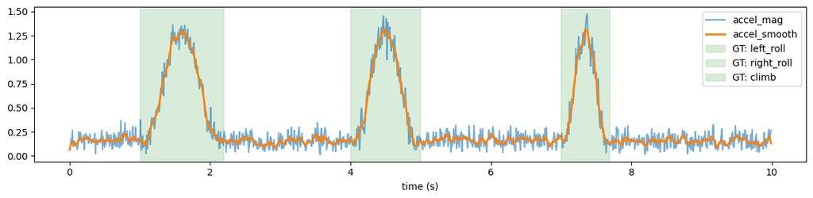

```python
import matplotlib.pyplot as plt
from maneuvers.preprocessing import compute_features_from_sequence

feats = compute_features_from_sequence(seq1)

def plot_sequence_with_segments(seq, feats, gt_segments, pred_segments=None):
    t = feats['t'].values
    plt.figure(figsize=(12,3))
    plt.plot(t, feats['accel_mag'], label='accel_mag', alpha=0.6)
    plt.plot(t, feats['accel_smooth'], label='accel_smooth', linewidth=2)
    for s,e,label in gt_segments:
        plt.axvspan(seq.timestamps[s], seq.timestamps[e-1], color='green', alpha=0.15, label=f'GT: {label}')
    if pred_segments:
        for s,e in pred_segments:
            plt.axvspan(seq.timestamps[s], seq.timestamps[e-1], color='red', alpha=0.12, label='Pred')
    plt.legend(loc='upper right')
    plt.xlabel('time (s)')
    plt.tight_layout()
    plt.show()

plot_sequence_with_segments(seq1, feats, seq1.segments)
```

## 4. Baseline threshold detection

Sweep a few thresholds and inspect results.

```
thr=0.2: 5 segments
```

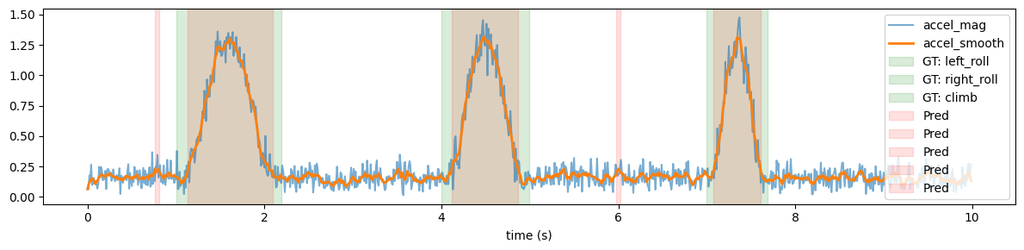

```
thr=0.4: 3 segments
```

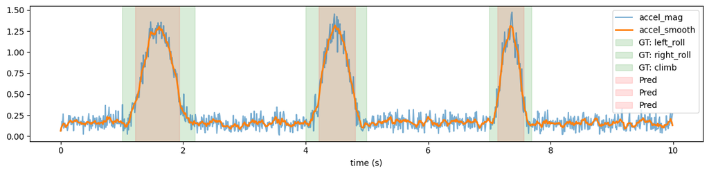

```
thr=0.6: 3 segments
```

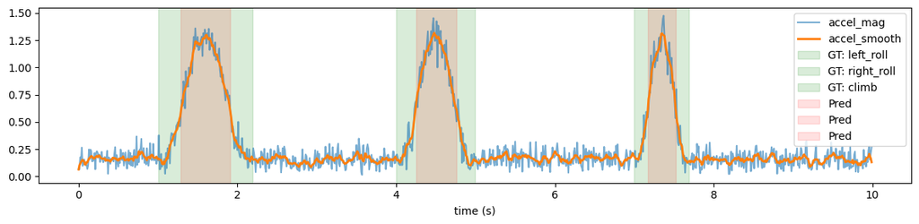

```
Selected preds: [(122, 195), (421, 482), (713, 757)]
```

```python
from maneuvers.detection import detect_segments

for thr in [0.2, 0.4, 0.6]:
    preds = detect_segments(feats, method='threshold', threshold=thr, min_len=5)
    print(f"thr={thr}: {len(preds)} segments")
    plot_sequence_with_segments(seq1, feats, seq1.segments, preds)

# store one detection result
preds = detect_segments(feats, method='threshold', threshold=0.4, min_len=5)
print('Selected preds:', preds)
```

## 5. Segment feature extraction and simple classifier

Aggregate per-ground-truth segment features and train a lightweight classifier (LogisticRegression). Save the trained model.

```python
from sklearn.linear_model import LogisticRegression
from maneuvers.classify import build_training_data_from_sequence, train_classifier, save_model, load_model, predict_segment_labels

X, y = build_training_data_from_sequence(seq1, feats)
print('Training examples:', X.shape, 'labels:', set(y))

# basic classifier (works on aggregated features)
clf = LogisticRegression(max_iter=1000)
clf.fit(X, y)

# predict labels for detected segments (simple aggregated features)
import numpy as np

from maneuvers.classify import segment_aggregated_features

def predict_labels_direct(clf, feats_df, segments):
    Xs = []
    for s,e in segments:
        seg_feat = segment_aggregated_features(feats_df, (s, e))
        Xs.append(seg_feat)
    preds_local = clf.predict(np.vstack(Xs))
    return list(preds_local)

pred_labels = predict_labels_direct(clf, feats, preds)
print('Predicted labels for predicted segments:', list(zip(preds, pred_labels)))

# save model for demo
import joblib
os.makedirs(os.path.join('..','..','examples'), exist_ok=True)
joblib.dump({'model': clf}, os.path.join('..','..','examples','model_demo_lr.joblib'))
print('Saved demo model to examples/model_demo_lr.joblib')
```

```
Training examples: (6, 9) labels: {'left_roll', 'right_roll', 'climb', 'none'}
```

```
Predicted labels for predicted segments: [((122, 195), np.str_('climb')), ((421, 482), np.str_('climb')), ((713, 757), np.str_('none'))]
Saved demo model to examples/model_demo_lr.joblib
```

## 6. Evaluate detection and classification

```
Detection evaluation: {'tp': 3, 'fp': 0, 'fn': 0, 'precision': 1.0, 'recall': 1.0, 'f1': 1.0}
Classification report (matched segments):
              precision    recall  f1-score   support

       climb       0.00      0.00      0.00       1.0
   left_roll       0.00      0.00      0.00       1.0
        none       0.00      0.00      0.00       0.0
  right_roll       0.00      0.00      0.00       1.0

    accuracy                           0.00       3.0
   macro avg       0.00      0.00      0.00       3.0
weighted avg       0.00      0.00      0.00       3.0
```

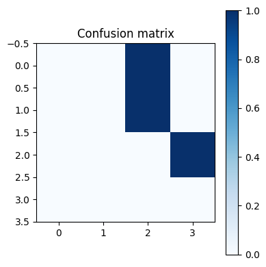

```python
from maneuvers.eval import evaluate_detection, segment_iou
from sklearn.metrics import classification_report, confusion_matrix, precision_recall_curve, roc_auc_score, roc_curve
import matplotlib.pyplot as plt

# detection evaluation
gt = [(s,e) for s,e,_ in seq1.segments]
det_res = evaluate_detection(gt, preds, iou_thresh=0.5)
print('Detection evaluation:', det_res)

# classification evaluation (match predicted -> gt by IoU)
# naive greedy matching
matches = []
used_pred = set()
used_gt = set()
for gi, g in enumerate(gt):
    best_i = -1
    best_iou = 0.0
    for pi, p in enumerate(preds):
        if pi in used_pred:
            continue
        iou = segment_iou(g,p)
        if iou > best_iou:
            best_iou = iou
            best_i = pi
    if best_i >= 0 and best_iou >= 0.5:
        matches.append((gi, best_i))
        used_pred.add(best_i)
        used_gt.add(gi)

true_labels = []
pred_labels_match = []
for gi, pi in matches:
    true_labels.append(seq1.segments[gi][2])
    pred_labels_match.append(pred_labels[pi])

if true_labels:
    print('Classification report (matched segments):')
    print(classification_report(true_labels, pred_labels_match))
    cm = confusion_matrix(true_labels, pred_labels_match, labels=list(set(true_labels+pred_labels_match)))
    plt.figure(figsize=(4,4))
    plt.imshow(cm, cmap='Blues')
    plt.title('Confusion matrix')
    plt.colorbar()
    plt.tight_layout()
    plt.show()
else:
    print('No matched segments to evaluate classification.')
```

## 7. Run the pipeline via CLI from the notebook

```python
import subprocess

print('\nCLI detect-synthetic:')
print(subprocess.run(['/root/.openclaw/workspace/projects/maneuvers/.venv/bin/python','-m','maneuvers.cli','detect-synthetic','--duration','5','--fs','50','--threshold','0.2'], capture_output=True, text=True).stdout)

print('\nCLI eval-synthetic:')
print(subprocess.run(['/root/.openclaw/workspace/projects/maneuvers/.venv/bin/python','-m','maneuvers.cli','eval-synthetic','--duration','5','--fs','50','--threshold','0.2'], capture_output=True, text=True).stdout)
```

```
CLI detect-synthetic:
```

```
Detected 2 segments: [(55, 104), (204, 244)]


CLI eval-synthetic:
```

```
{'tp': 2, 'fp': 0, 'fn': 0, 'precision': 1.0, 'recall': 1.0, 'f1': 1.0}
```

## 8. CI workflow snippet (GitHub Actions)

```python
ci_yaml = '''name: CI

on:
  push:
    branches: [ main ]
  pull_request:
    branches: [ main ]

jobs:
  test:
    runs-on: ubuntu-latest
    steps:
      - uses: actions/checkout@v4
      - uses: actions/setup-python@v4
        with:
          python-version: 3.10
      - run: |
          python -m pip install --upgrade pip
          pip install -r requirements.txt
          pip install -e .
          pip install pytest black flake8 nbval nbconvert
      - run: pytest -q --nbval-lax examples/notebooks/detection_classification_demo.ipynb
      - run: black --check .
      - run: flake8 .
      - run: jupyter nbconvert --execute --to html examples/notebooks/detection_classification_demo.ipynb --ExecutePreprocessor.timeout=600
'''
print(ci_yaml)
```

```
name: CI

on:
  push:
    branches: [ main ]
  pull_request:
    branches: [ main ]

jobs:
  test:
    runs-on: ubuntu-latest
    steps:
      - uses: actions/checkout@v4
      - uses: actions/setup-python@v4
        with:
          python-version: 3.10
      - run: |
          python -m pip install --upgrade pip
          pip install -r requirements.txt
          pip install -e .
          pip install pytest black flake8 nbval nbconvert
      - run: pytest -q --nbval-lax examples/notebooks/detection_classification_demo.ipynb
      - run: black --check .
      - run: flake8 .
      - run: jupyter nbconvert --execute --to html examples/notebooks/detection_classification_demo.ipynb --ExecutePreprocessor.timeout=600
```

## 9. Save outputs and upload artifacts

Serialize detection results and save to `artifacts/` so CI can upload them for inspection.

```python
os.makedirs(os.path.join('..','..','artifacts'), exist_ok=True)
import json
with open(os.path.join('..','..','artifacts','detection_results.json'), 'w') as fh:
    json.dump({'gt': gt, 'preds': preds}, fh)
print('Wrote artifacts to artifacts/')
```

```
Wrote artifacts to artifacts/
```

## 10. Utilities & next steps

- Add richer features (spectral features, rolling stats) in `maneuvers.preprocessing`.
- Add cross-validation and model serialization routines in `maneuvers.classify` and improved plotting utilities.
- Integrate nbval into CI to ensure notebooks remain executable on PRs.

```python
# 6. Evaluate detection and classification
from maneuvers.eval import evaluate_detection, segment_iou
from sklearn.metrics import classification_report, confusion_matrix

# detection evaluation
gt = [(s,e) for s,e,_ in seq1.segments]
det_res = evaluate_detection(gt, preds, iou_thresh=0.5)
print('Detection evaluation:', det_res)

# classification evaluation (match predicted -> gt by IoU)
# naive greedy matching
matches = []
used_pred = set()
used_gt = set()
for gi, g in enumerate(gt):
    best_i = -1
    best_iou = 0.0
    for pi, p in enumerate(preds):
        if pi in used_pred:
            continue
        iou = segment_iou(g,p)
        if iou > best_iou:
            best_iou = iou
            best_i = pi
    if best_i >= 0 and best_iou >= 0.5:
        matches.append((gi, best_i))
        used_pred.add(best_i)
        used_gt.add(gi)

true_labels = []
pred_labels_match = []
for gi, pi in matches:
    true_labels.append(seq1.segments[gi][2])
    pred_labels_match.append(pred_labels[pi])

if true_labels:
    print('Classification report (matched segments):')
    print(classification_report(true_labels, pred_labels_match))
else:
    print('No matched segments to evaluate classification.')

# 7. Run CLI commands programmatically
import subprocess

print('\nCLI detect-synthetic:')
print(subprocess.run(['/root/.openclaw/workspace/projects/maneuvers/.venv/bin/python','-m','maneuvers.cli','detect-synthetic','--duration','5','--fs','50','--threshold','0.2'], capture_output=True, text=True).stdout)

print('\nCLI eval-synthetic:')
print(subprocess.run(['/root/.openclaw/workspace/projects/maneuvers/.venv/bin/python','-m','maneuvers.cli','eval-synthetic','--duration','5','--fs','50','--threshold','0.2'], capture_output=True, text=True).stdout)

# 8. CI workflow snippet (displayed for convenience)
ci_yaml = '''name: CI

on:
  push:
    branches: [ main ]
  pull_request:
    branches: [ main ]

jobs:
  test:
    runs-on: ubuntu-latest
    steps:
      - uses: actions/checkout@v4
      - uses: actions/setup-python@v4
        with:
          python-version: 3.10
      - run: |
          python -m pip install --upgrade pip
          pip install -r requirements.txt
          pip install -e .
          pip install pytest black flake8
      - run: pytest -q
      - run: black --check .
      - run: flake8 .
      - run: jupyter nbconvert --execute --to html examples/notebooks/detection_classification_demo.ipynb --ExecutePreprocessor.timeout=600
'''
print('\nCI workflow preview (snippet):\n')
print(ci_yaml)

# 9. Save artifacts
os.makedirs(os.path.join('..','..','artifacts'), exist_ok=True)
import json
with open(os.path.join('..','..','artifacts','detection_results.json'), 'w') as fh:
    json.dump({'gt': gt, 'preds': preds}, fh)
print('Wrote artifacts to artifacts/')
```

```
Detection evaluation: {'tp': 3, 'fp': 0, 'fn': 0, 'precision': 1.0, 'recall': 1.0, 'f1': 1.0}
Classification report (matched segments):
              precision    recall  f1-score   support

       climb       0.00      0.00      0.00       1.0
   left_roll       0.00      0.00      0.00       1.0
        none       0.00      0.00      0.00       0.0
  right_roll       0.00      0.00      0.00       1.0

    accuracy                           0.00       3.0
   macro avg       0.00      0.00      0.00       3.0
weighted avg       0.00      0.00      0.00       3.0


CLI detect-synthetic:
```

```
Detected 2 segments: [(55, 104), (204, 244)]


CLI eval-synthetic:
```

```
{'tp': 2, 'fp': 0, 'fn': 0, 'precision': 1.0, 'recall': 1.0, 'f1': 1.0}


CI workflow preview (snippet):

name: CI

on:
  push:
    branches: [ main ]
  pull_request:
    branches: [ main ]

jobs:
  test:
    runs-on: ubuntu-latest
    steps:
      - uses: actions/checkout@v4
      - uses: actions/setup-python@v4
        with:
          python-version: 3.10
      - run: |
          python -m pip install --upgrade pip
          pip install -r requirements.txt
          pip install -e .
          pip install pytest black flake8
      - run: pytest -q
      - run: black --check .
      - run: flake8 .
      - run: jupyter nbconvert --execute --to html examples/notebooks/detection_classification_demo.ipynb --ExecutePreprocessor.timeout=600

Wrote artifacts to artifacts/
```